# Performance Evaluation

Week 7 R-lab  
Zhaohu(Jonathan) Fan

06/24/2021

# Data Partitioning

- 1. Define Goal
- 2. Get Data
- 3. Explore & Visualize Series
- 4. Pre-Process Data
- 5. $\color{red}{\text{Partition Series}}$
- 6. Apply Forecasting Method(s)
- 7. Evaluate & Compare Performance
- 8. Implement Forecasts/System

# Training & Test Sets

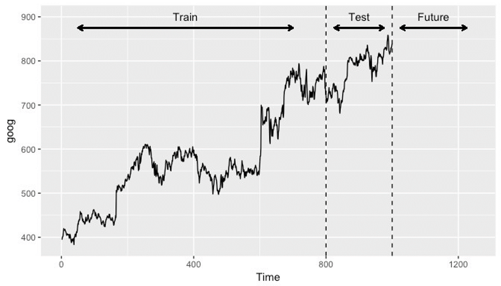

- **Data Fit**: Fit model to **training period** . We aim to estimate the model parameters.
- **Predictive Accuracy**: Assess performance on **test period**. We aim to check the performance of the forecasting method.
- Deploy model by joining **training + validation** to forecast future.

# Data Example

- Back in 2001, a store wanted to use the data to forecast sales for the next 12 months (year 2002).
- They hired an analyst to generate forecasts. The analyst first partitioned the data into training and validation periods, with the validation period containing the last 12 months of data (year 2001).
- She/he then fit a forecasting model to sales, using the training period.

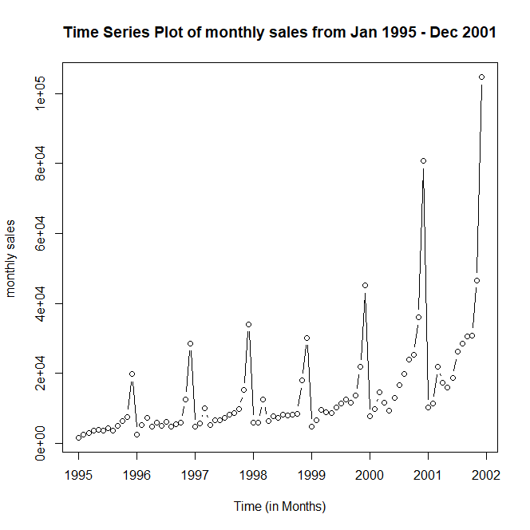

# Data Example (cont’d)

Souvenir Sales: The file `SouvenirSales.xls` contains monthly sales for a souvenir shop at a beach resort town in Queensland, Australia, between 1995 and 2001.

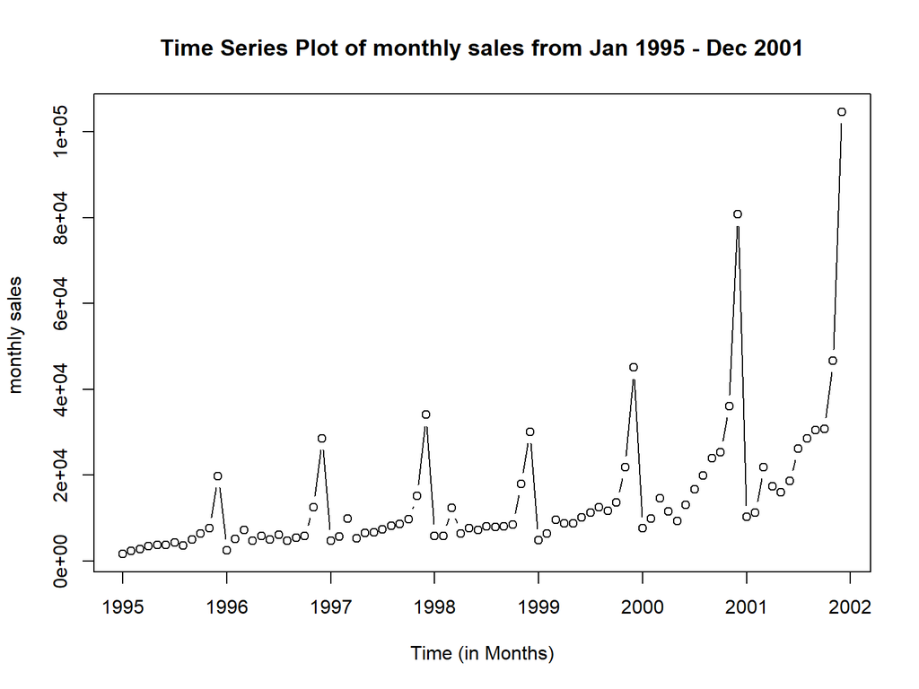

```r
library(readxl)
library(quantmod)
setwd("C:/Users/fanzh/OneDrive - University of Cincinnati/UC_couse/000_Teaching_4090_SS21/uc-bana7052-master/docs/slides")
df <- read_xlsx(path = "SouvenirSales.xlsx")
Sales_ts<- ts(df$Sales, start = as.yearmon("1995-01"),end = as.yearmon("2001-12"),freq = 12)
plot(Sales_ts,type = "b",xlab= "Time (in Months)", ylab = "monthly sales ", main = "Time Series Plot of monthly sales from Jan 1995 - Dec 2001")
```

# Data Example (cont’d)

- Partition the data in R

```r
# Data partition
library(tidyverse)
#The filter() function is used to subset a data frame, retaining all rows that satisfy your conditions.
train <- filter(df, Date < as.Date("2001-01-01"))
test  <- filter(df, Date >= as.Date("2001-01-01"))
head(train, 12)
```

```
## # A tibble: 12 x 2
##    Date                 Sales
##    <dttm>               <dbl>
##  1 1995-01-01 00:00:00  1665.
##  2 1995-02-01 00:00:00  2398.
##  3 1995-03-01 00:00:00  2841.
##  4 1995-04-01 00:00:00  3547.
##  5 1995-05-01 00:00:00  3753.
##  6 1995-06-01 00:00:00  3715.
##  7 1995-07-01 00:00:00  4350.
##  8 1995-08-01 00:00:00  3566.
##  9 1995-09-01 00:00:00  5022.
## 10 1995-10-01 00:00:00  6423.
## 11 1995-11-01 00:00:00  7601.
## 12 1995-12-01 00:00:00 19756.
```

```r
head(test, 12)
```

```
## # A tibble: 12 x 2
##    Date                  Sales
##    <dttm>                <dbl>
##  1 2001-01-01 00:00:00  10243.
##  2 2001-02-01 00:00:00  11267.
##  3 2001-03-01 00:00:00  21827.
##  4 2001-04-01 00:00:00  17357.
##  5 2001-05-01 00:00:00  15998.
##  6 2001-06-01 00:00:00  18602.
##  7 2001-07-01 00:00:00  26155.
##  8 2001-08-01 00:00:00  28587.
##  9 2001-09-01 00:00:00  30505.
## 10 2001-10-01 00:00:00  30821.
## 11 2001-11-01 00:00:00  46634.
## 12 2001-12-01 00:00:00 104661.
```

# Data Example (cont’d)

- Create time series objects

```r
train.ts <- ts(train["Sales"], start = c(1995, 1), frequency = 12)
test.ts <- ts(test["Sales"], start = c(2001, 1), frequency = 12)
head(train.ts, 12)
```

```
##          Sales
##  [1,]  1664.81
##  [2,]  2397.53
##  [3,]  2840.71
##  [4,]  3547.29
##  [5,]  3752.96
##  [6,]  3714.74
##  [7,]  4349.61
##  [8,]  3566.34
##  [9,]  5021.82
## [10,]  6423.48
## [11,]  7600.60
## [12,] 19756.21
```

```r
head(test.ts, 12)
```

```
##           Sales
##  [1,]  10243.24
##  [2,]  11266.88
##  [3,]  21826.84
##  [4,]  17357.33
##  [5,]  15997.79
##  [6,]  18601.53
##  [7,]  26155.15
##  [8,]  28586.52
##  [9,]  30505.41
## [10,]  30821.33
## [11,]  46634.38
## [12,] 104660.67
```

# Data Example (cont’d)

- Training period

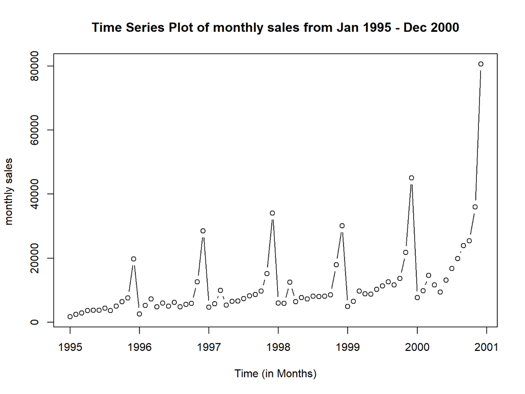

```r
plot(train.ts,type = "b",xlab= "Time (in Months)", ylab = "monthly sales ", main = "Time Series Plot of monthly sales from Jan 1995 - Dec 2000")
```

# Data Example (cont’d)

- Test period

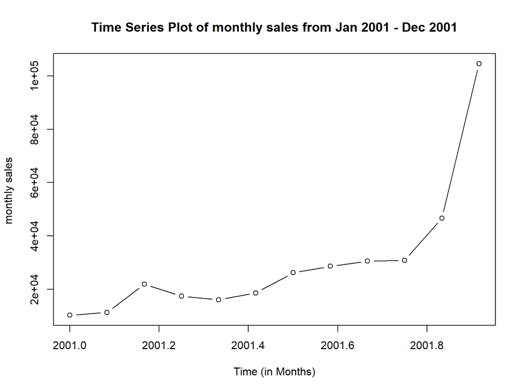

```r
plot(test.ts,type = "b",xlab= "Time (in Months)", ylab = "monthly sales ", main = "Time Series Plot of monthly sales from Jan 2001 - Dec 2001")
```

# Forecasting Method(s)

- 1. Define Goal
- 2. Get Data
- 3. Explore & Visualize Series
- 4. Pre-Process Data
- 5. Partition Series
- 6. $\color{red}{\text{Apply Forecasting Method(s): Naïve Forecast and Seasonal Naïve Forecast}}$
- 7. Evaluate & Compare Performance
- 8. Implement Forecasts/System

# Naïve Model

- Forecasts equal to last observed value.
- Forecasts: $\hat{y}_{T+h|T} =y_T$.
- Perform a naïve forecast method with the `naive` function.
- We can print off the model summary with `summary`, which provides us with the residual standard deviation, some error measures (which we will cover later), and the actual forecasted values.

```r
 # Naïve Model
library(forecast)
naive.model<-naive(train.ts, 12)
summary(naive.model)
```

```
##
## Forecast method: Naive method
##
## Model Information:
## Call: naive(y = train.ts, h = 12)
##
## Residual sd: 10460.7283
##
## Error measures:
##                    ME     RMSE      MAE       MPE     MAPE    MASE       ACF1
## Training set 1113.477 10460.73 5506.879 -25.27554 61.16191 1.47054 -0.1968879
##
## Forecasts:
##          Point Forecast    Lo 80     Hi 80     Lo 95    Hi 95
## Jan 2001       80721.71 67315.75  94127.67 60219.059 101224.4
## Feb 2001       80721.71 61762.82  99680.60 51726.583 109716.8
## Mar 2001       80721.71 57501.90 103941.52 45210.077 116233.3
## Apr 2001       80721.71 53909.78 107533.64 39716.409 121727.0
## May 2001       80721.71 50745.07 110698.35 34876.389 126567.0
## Jun 2001       80721.71 47883.94 113559.48 30500.677 130942.7
## Jul 2001       80721.71 45252.87 116190.55 26476.795 134966.6
## Aug 2001       80721.71 42803.92 118639.50 22731.457 138712.0
## Sep 2001       80721.71 40503.82 120939.60 19213.758 142229.7
## Oct 2001       80721.71 38328.33 123115.09 15886.636 145556.8
## Nov 2001       80721.71 36259.16 125184.26 12722.110 148721.3
## Dec 2001       80721.71 34282.09 127161.33  9698.445 151745.0
```

# Seasonal Naïve Model

- Forecasts equal to last value from same season.
- Forecasts: $\hat{y}_{T+h|T} =y_{T+h-m(k+1)}$, where $m=$ seasonal period and $k$ is the integer part of $(h-1)/m$.
- Perform a seasonal naïve forecast method with the `snaive` function.

```r
 # Seasonal Naïve Model
library(forecast)
snaive.model<-snaive(train.ts, 12)
snaive.model
```

```
##          Point Forecast      Lo 80    Hi 80      Lo 95    Hi 95
## Jan 2001        7615.03  -673.8117 15903.87 -5061.6594 20291.72
## Feb 2001        9849.69  1560.8483 18138.53 -2826.9994 22526.38
## Mar 2001       14558.40  6269.5583 22847.24  1881.7106 27235.09
## Apr 2001       11587.33  3298.4883 19876.17 -1089.3594 24264.02
## May 2001        9332.56  1043.7183 17621.40 -3344.1294 22009.25
## Jun 2001       13082.09  4793.2483 21370.93   405.4006 25758.78
## Jul 2001       16732.78  8443.9383 25021.62  4056.0906 29409.47
## Aug 2001       19888.61 11599.7683 28177.45  7211.9206 32565.30
## Sep 2001       23933.38 15644.5383 32222.22 11256.6906 36610.07
## Oct 2001       25391.35 17102.5083 33680.19 12714.6606 38068.04
## Nov 2001       36024.80 27735.9583 44313.64 23348.1106 48701.49
## Dec 2001       80721.71 72432.8683 89010.55 68045.0206 93398.40
```

# Forecast Accuracy Measures

- 1. Define Goal
- 2. Get Data
- 3. Explore & Visualize Series
- 4. Pre-Process Data
- 5. Partition Series
- 6. Apply Forecasting Method(s)
- 7. $\color{red}{\text{Evaluate & Compare Performance}}$
- 8. Implement Forecasts/System

# Assessing Residuals

When applying a forecasting method, it is important to always check that the residuals are well-behaved (i.e., no outliers or patterns) and resemble white noise.

- Essential assumptions for an appropriate forecasting model include residuals being:
  - Uncorrelated
  - Centered at mean zero
- Furthermore, the prediction intervals are computed assuming that the residuals:
  - Have constant variance
  - Are normally distributed

# Assessing Residuals (cont’d)

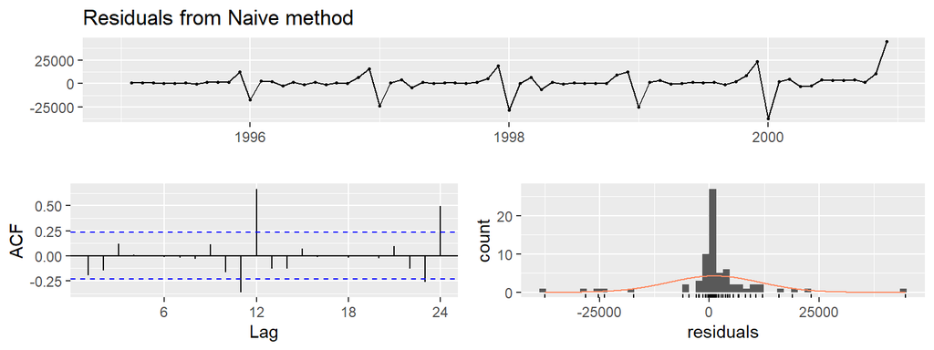

```
##
##  Ljung-Box test
##
## data:  Residuals from Naive method
## Q* = 62.944, df = 14, p-value = 3.551e-08
##
## Model df: 0.   Total lags used: 14
```

```r
# measuring forecast accuracy
checkresiduals(naive.model)
```

# Assessing Residuals (cont’d)

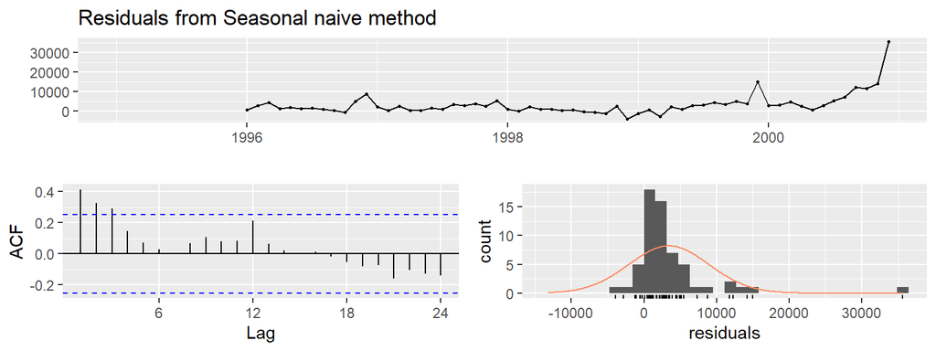

```
##
##  Ljung-Box test
##
## data:  Residuals from Seasonal naive method
## Q* = 30.971, df = 14, p-value = 0.005596
##
## Model df: 0.   Total lags used: 14
```

```r
# measuring forecast accuracy
checkresiduals(snaive.model)
```

# Forecast Accuracy Measures

- Commonly used to assess the predictive accuracy of a forecasting method
- The measures are based on the **test data set**, which serves as a more objective basis than the training period to assess predictive accuracy

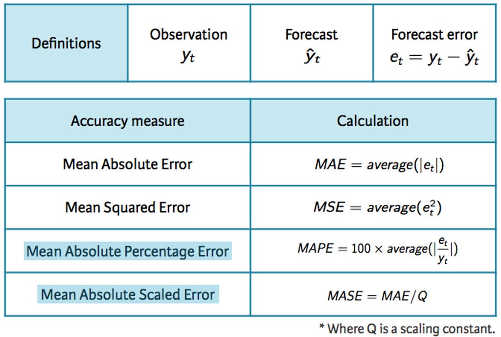

# Forecast Accuracy Measures (cont’d)

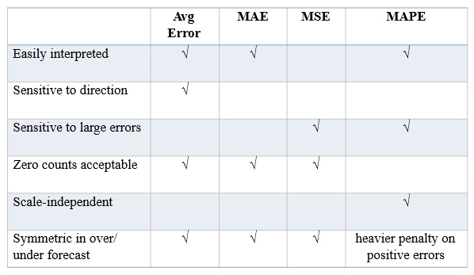

# Forecast Accuracy Measures (cont’d)

- Naïve model

```r
# measuring forecast accuracy
accuracy(naive.model, test.ts)
```

```
##                      ME     RMSE       MAE        MPE      MAPE     MASE
## Training set   1113.477 10460.73  5506.879  -25.27554  61.16191  1.47054
## Test set     -50500.288 56099.07 54490.114 -287.13834 290.95050 14.55087
##                    ACF1 Theil's U
## Training set -0.1968879        NA
## Test set      0.3182456  6.649124
```

# Forecast Accuracy Measures (cont’d)

- Seasonal Naïve model

```r
# measuring forecast accuracy
accuracy(snaive.model, test.ts)
```

```
##                    ME     RMSE      MAE      MPE     MAPE     MASE      ACF1
## Training set 3401.361 6467.818 3744.801 22.39270 25.64127 1.000000 0.4140974
## Test set     7828.278 9542.346 7828.278 27.27926 27.27926 2.090439 0.2264895
##              Theil's U
## Training set        NA
## Test set     0.7373759
```

# Perdicition Intervals

- A prediction interval gives an interval within which we expect to lie with a specified probability.
- Allows us to understand the **uncertainty** that exists in a forecast.
- **Should always report $\color{red}{\text{point estimate}}$ and $\color{red}{\text{prediction intervals}}$ for forecasts**.
- It is common to calculate 80% intervals and 95% intervals, although any percentage may be used.

# Data Example (cont’d): Prediction Intervals

- Naïve Model
- Blue line represents point estimates, which are equal to the last observed value (It’s a flat line).
- Colored bands represent our 80% and 95% prediction confidence interval.

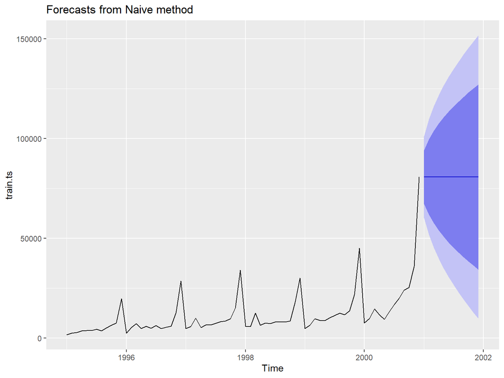

```r
 #  Naïve Model
autoplot(naive.model)
```

# Perdicition Intervals (cont’d)

- Naïve Model
- We can print off the model summary with `summary`, which provides us with the residual standard deviation, some error measures, and the actual forecasted values.

```r
 # Naïve Model
library(forecast)
naive.model<-naive(train.ts, 12)
summary(naive.model)
```

```
##
## Forecast method: Naive method
##
## Model Information:
## Call: naive(y = train.ts, h = 12)
##
## Residual sd: 10460.7283
##
## Error measures:
##                    ME     RMSE      MAE       MPE     MAPE    MASE       ACF1
## Training set 1113.477 10460.73 5506.879 -25.27554 61.16191 1.47054 -0.1968879
##
## Forecasts:
##          Point Forecast    Lo 80     Hi 80     Lo 95    Hi 95
## Jan 2001       80721.71 67315.75  94127.67 60219.059 101224.4
## Feb 2001       80721.71 61762.82  99680.60 51726.583 109716.8
## Mar 2001       80721.71 57501.90 103941.52 45210.077 116233.3
## Apr 2001       80721.71 53909.78 107533.64 39716.409 121727.0
## May 2001       80721.71 50745.07 110698.35 34876.389 126567.0
## Jun 2001       80721.71 47883.94 113559.48 30500.677 130942.7
## Jul 2001       80721.71 45252.87 116190.55 26476.795 134966.6
## Aug 2001       80721.71 42803.92 118639.50 22731.457 138712.0
## Sep 2001       80721.71 40503.82 120939.60 19213.758 142229.7
## Oct 2001       80721.71 38328.33 123115.09 15886.636 145556.8
## Nov 2001       80721.71 36259.16 125184.26 12722.110 148721.3
## Dec 2001       80721.71 34282.09 127161.33  9698.445 151745.0
```

# Perdicition Intervals (cont’d)

```r
 # Seasonal Naïve Model
library(forecast)
snaive.model<-snaive(train.ts, 12)
snaive.model
```

```
##          Point Forecast      Lo 80    Hi 80      Lo 95    Hi 95
## Jan 2001        7615.03  -673.8117 15903.87 -5061.6594 20291.72
## Feb 2001        9849.69  1560.8483 18138.53 -2826.9994 22526.38
## Mar 2001       14558.40  6269.5583 22847.24  1881.7106 27235.09
## Apr 2001       11587.33  3298.4883 19876.17 -1089.3594 24264.02
## May 2001        9332.56  1043.7183 17621.40 -3344.1294 22009.25
## Jun 2001       13082.09  4793.2483 21370.93   405.4006 25758.78
## Jul 2001       16732.78  8443.9383 25021.62  4056.0906 29409.47
## Aug 2001       19888.61 11599.7683 28177.45  7211.9206 32565.30
## Sep 2001       23933.38 15644.5383 32222.22 11256.6906 36610.07
## Oct 2001       25391.35 17102.5083 33680.19 12714.6606 38068.04
## Nov 2001       36024.80 27735.9583 44313.64 23348.1106 48701.49
## Dec 2001       80721.71 72432.8683 89010.55 68045.0206 93398.40
```